# TRAM-DAG — a didactic introduction with `tramdag`

*TRAM-DAGs* ([paper](https://arxiv.org/abs/2503.16206), [original R/Keras code](https://github.com/tensorchiefs/tram-dag)) are causal models that use **structured transformation functions** to map a latent representation $Z$ to the observed data $X$. For continuous variables they are **bijective causal models**, so once trained a single model answers all three rungs of Pearl's causal hierarchy:

| rung | query | `tramdag` call |
| --- | --- | --- |
| L1 association | $p(x)$, sampling | `flow.log_prob(df)`, `flow.sample(n)` |
| L2 intervention | $p(x \mid do(x_j{=}a))$ | `flow.sample(n, do={...})`, `flow.pmf(df, node, do={...})` |
| L3 counterfactual | "what would $x_i$ have been, had $x_j$ been $a$?" | `flow.abduct(df)` + `flow.sample(do={...}, u=u)` |

This notebook walks through the model exactly as written in the paper notation, builds a small data-generating process (DGP) **inside the model family**, fits a `CausalFlowDAG`, and verifies every claim against the known ground truth.

(Notebook format and how to run it: see `notebooks/README.md`.)

## 1. The model

We assume a causal ordering of the variables. A TRAM-DAG fits, for each variable, a monotone **transformation function** $h$ (bijective, monotone increasing) that maps the observed value to a latent scale, conditional on the variable's parents:

$$ \begin{align*} z_1 &= h(x_1) \\ z_2 &= h(x_2 \mid x_1)\\ z_3 &= h(x_3 \mid x_1, x_2) \\ \dots &\\ z_p &= h(x_p \mid x_1, x_2, \dots, x_{p-1}) \end{align*} $$

This **observed → latent** map is the convention of the paper (Eq. 2, $F_{X\mid\mathrm{pa}}(x)=F_U\!\big(h(x\mid\mathrm{pa})\big)$) and of the code (`z = h(x) + shift`). It is also the **training direction**: $h$ is evaluated *directly* to score the likelihood (cheap). **Sampling** runs the inverse $x_i = h^{-1}(z_i \mid \mathrm{pa})$, which has no closed form and is solved by bracketed bisection — the costlier direction.

Together the $h$'s form one **triangular** flow; each variable may depend only on a *subset* of its predecessors — its causal parents $\mathrm{pa}(x_i)$ — so the Jacobian sparsity of the flow *is* the DAG.

For the latents $z_1,\dots,z_p$ we assume a **standard logistic** distribution. That choice is what makes the fitted parameters interpretable: shifts on the latent scale are **log-odds ratios** (Section 6).

### The four components

To keep a valid interpretation, the transformation is decomposed **additively on the latent scale**. Each node's $h$ (observed → latent, as above) is

$$ z_i \;=\; h(x_i \mid \mathrm{pa}(x_i)) \;=\; \underbrace{f_\theta(x_i)}_{\text{intercept}} \;+\; \underbrace{\textstyle\sum_j \beta_{ij}\, x_j}_{\text{linear shifts (LS)}} \;+\; \underbrace{\textstyle\sum_k g_{ik}(x_k)}_{\text{complex shifts (CS)}} , $$

with every causal parent assigned to exactly one term. Take $x_5$ with parents $\mathrm{pa}(x_5) = \{x_1, x_2, x_4\}$ as the running example:

- **Simple intercept (SI):** $f_\theta(x_5)$ has *constant* parameters $\theta$ — a flexible monotone baseline transformation (here: a Bernstein polynomial), the same for every observation.
- **Complex intercept (CI):** the parameters $\theta$ of $f_\theta(x_5)$ are themselves a function of (a subset of) the parents — the whole transformation bends with the parent, allowing interactions beyond additive shifts.
- **Linear shift (LS):** $\beta_{51} x_1 + \beta_{52} x_2$ — one interpretable number per parent.
- **Complex shift (CS):** $g(x_4)$ — an unrestricted (MLP) function of the parent, still *additive* on the latent scale.

so that **sampling** (the inverse direction) only has to invert the intercept — the shifts move to the other side:

$$ x_5 = h^{-1}(z_5 \mid x_1, x_2, x_4) = f_\theta^{-1}\!\Big(z_5 - \underbrace{\beta_{51} x_1 + \beta_{52} x_2}_{\text{LS}} - \underbrace{g(x_4)}_{\text{CS}}\Big). $$

In `tramdag` each node declares its transformation as an **additive formula of terms** — `terms=[...]` — built from the constructors `I` (intercept), `LS` (linear shift) and `CS` (complex shift), each naming the parent(s) it depends on:

| paper component | `tramdag` |
| --- | --- |
| SI — baseline $f_\theta(x_i)$, constant $\theta$ | automatic: every node owns a monotone transform (`bernstein` / `spline` / `affine`); with no intercept term its $\theta$ is a free parameter vector |
| CI — $\theta$ depends on parents | `I("X1")` (several `I(...)` parents feed **one joint** network → interactions) |
| LS — $\beta_{ij} x_j$ | `LS("X1")` (a single weight, no bias) |
| CS — $g_{ik}(x_k)$ | `CS("X1")` (64-128-64 MLP, additive) |

### Gallery: a `terms=[...]` spec *is* an additive decomposition

Read every spec line as a recipe for $h(x_i \mid \mathrm{pa})$. Each parent lands in **exactly one** term — the intercept (the *shape*) or one shift — and the table shows the resulting decomposition for a single continuous target $X_3$:

| `terms=` | $z_3 = h(x_3 \mid \mathrm{pa})$ | what carries each parent |
| --- | --- | --- |
| `[]` (source) | $f_\theta(x_3)$ | `SimpleIntercept` — $\theta$ a free vector |
| `[LS("X1")]` | $f_\theta(x_3) + \beta\,x_1$ | `LinearShift` — **one number** $\beta$ |
| `[CS("X1")]` | $f_\theta(x_3) + g(x_1)$ | `ComplexShift` — additive MLP $g$ |
| `[I("X1")]` | $f_{\theta(x_1)}(x_3)$ | `ComplexIntercept` — **no shift term**; $\theta$ (the whole shape) bends with $x_1$ |
| `[LS("X1"), CS("X2")]` | $f_\theta(x_3) + \beta x_1 + g(x_2)$ | one `LinearShift` + one `ComplexShift` (the model fitted below) |
| `[CS("X1", "X2")]` | $f_\theta(x_3) + g(x_1, x_2)$ | **one joint** `ComplexShift` — an interaction in the shift |
| `[I("X1"), I("X2")]` | $f_{\theta(x_1) + \theta(x_2)}(x_3)$ | **additive** CI — each parent reshapes the transform independently (two nets summed) |
| `[I("X1", "X2")]` | $f_{\theta(x_1,x_2)}(x_3)$ | **one joint** `ComplexIntercept` over both parents (they interact) |

For an **ordinal** target the intercept is not a Bernstein curve but the vector of ordered cutpoints $\vartheta_k(\mathrm{pa})$, and the shift is **subtracted**: $P(Y \le k \mid \mathrm{pa}) = \sigma\big(\vartheta_k - \text{shift}\big)$ — `LS` and `CS` terms enter that shift exactly as above.

The odd one out is **`I(...)`** (a complex intercept): it is the only term that is *not* an additive shift — it moves the parent into the intercept, so there is no separate summand and no single-number coefficient to read off (§6). That is the interpretability price of letting the transformation's *shape* depend on the parent.

```python
import matplotlib.pyplot as plt
import numpy as np
import pandas as pd
import torch

from tramdag import CS, LS, CausalFlowDAG, ContinuousNode, OrdinalNode

plt.rcParams["figure.dpi"] = 110
```

## 2. A hand-built DGP — *inside* the model family

To verify everything against ground truth we now build a small structural causal model **by hand**, with logistic latents, exactly in the form above (this mirrors the construction in [`triangle_structured_continous.R`](https://github.com/tensorchiefs/tram-dag/blob/main/summerof24/triangle_structured_continous.R)). The DAG is $X_1 \to X_2 \to X_3 \leftarrow X_1$ plus an ordinal outcome $X_3 \to Y$:

$$ \begin{aligned} z_1 &= h_1(x_1) = 1.2\,x_1 - 0.4 &&\Rightarrow\; x_1 = (z_1 + 0.4)/1.2 \\[2pt] z_2 &= h_2(x_2) + \beta_{21} x_1, \quad h_2(x) = 2x + 1,\; \beta_{21} = 1.5 &&\Rightarrow\; x_2 = (z_2 - 1.5\,x_1 - 1)/2 \\[2pt] z_3 &= h_3(x_3) + \beta_{31} x_1 + g(x_2), \quad h_3(x) = \sinh(x),\; \beta_{31} = 0.8,\; g(x) = \tfrac12 x^2 &&\Rightarrow\; x_3 = \operatorname{asinh}\!\big(z_3 - 0.8\,x_1 - \tfrac12 x_2^2\big) \\[2pt] P(Y \le k) &= \sigma(\vartheta_k - \beta_{Y} x_3), \quad \vartheta = (-2, 0, 1.5),\; \beta_{Y} = 1 &&\Rightarrow\; y = \#\{k : z_4 > \vartheta_k - \beta_Y x_3\} \end{aligned} $$

Note the conventions (they are the TRAM conventions, and tests in this repo pin them):

- continuous nodes: the shift is **added** on the latent scale, $z = h(x) + \text{shift}$;
- ordinal nodes: the shift is **subtracted** inside the sigmoid, $P(Y \le k) = \sigma(\vartheta_k - \text{shift})$, with increasing cutpoints $\vartheta_k$ (an *ordered logit*). The flip makes a positive $\beta$ push $Y$ towards *higher* categories.

$X_2$ enters $X_3$ through a **complex shift** quadratic shift $g(x_2)=\tfrac12 x_2^2$ that a linear shift cannot represent. We will come to that later.

```python
TRUE = dict(b21=1.5, b31=0.8, bY=1.0, theta_Y=np.array([-2.0, 0.0, 1.5]))


def rlogis(rng, n):
    """Standard logistic draws."""
    u = rng.uniform(1e-9, 1 - 1e-9, size=n)
    return np.log(u) - np.log1p(-u)


def g_cs(x2):
    """The true complex shift of X2 on X3."""
    return 0.5 * x2**2


def simulate(n, rng, x1=None, z=None):
    """Sample from the SCM. `x1` overrides the source node (= do(X1)),
    `z` reuses given latents (= counterfactuals).
    """
    if z is None:
        z = {k: rlogis(rng, n) for k in ["z1", "z2", "z3", "z4"]}
    if x1 is None:
        x1 = (z["z1"] + 0.4) / 1.2
    else:
        x1 = np.full(n, float(x1))
    x2 = (z["z2"] - TRUE["b21"] * x1 - 1.0) / 2.0
    x3 = np.arcsinh(z["z3"] - TRUE["b31"] * x1 - g_cs(x2))
    cut = TRUE["theta_Y"][None, :] - TRUE["bY"] * x3[:, None]
    y = (z["z4"][:, None] > cut).sum(axis=1)
    df = pd.DataFrame({"X1": x1, "X2": x2, "X3": x3, "Y": y.astype(float)})
    return df, z


rng = np.random.default_rng(1)
df, z_obs = simulate(6000, rng)  # keep the latents -> true counterfactuals
train_df, val_df = df.iloc[:5000], df.iloc[5000:]
df.describe().round(2)
```

|  | X1 | X2 | X3 | Y |
| --- | --- | --- | --- | --- |
| count | 6000.00 | 6000.00 | 6000.00 | 6000.00 |
| mean | 0.34 | -0.75 | -0.73 | 1.24 |
| std | 1.51 | 1.44 | 1.41 | 1.03 |
| min | -7.38 | -7.34 | -4.18 | 0.00 |
| 25% | -0.57 | -1.68 | -1.86 | 0.00 |
| 50% | 0.34 | -0.74 | -0.99 | 1.00 |
| 75% | 1.26 | 0.16 | 0.43 | 2.00 |
| max | 7.70 | 5.01 | 2.85 | 3.00 |

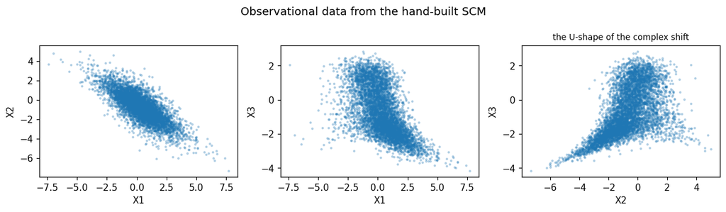

```python
fig, axes = plt.subplots(1, 3, figsize=(11, 3.2))
for ax, (a, b) in zip(axes, [("X1", "X2"), ("X1", "X3"), ("X2", "X3")]):
    ax.scatter(df[a], df[b], s=3, alpha=0.25)
    ax.set_xlabel(a), ax.set_ylabel(b)
axes[2].set_title("the U-shape of the complex shift", fontsize=9)
fig.suptitle("Observational data from the hand-built SCM")
fig.tight_layout()
plt.show()
```

## 3. Specifying the DAG and fitting the flow

The model spec *is* the labelled adjacency matrix, written per node. Each continuous node automatically gets its monotone baseline transformation (default: Bernstein polynomial with 20 coefficients, the TRAM-faithful choice); the edges declare how each parent enters.

Fitting maximises the joint likelihood. Because the flow is triangular, the negative log-likelihood **decomposes per node** ($\log p(x) = \sum_i \log p(x_i \mid \mathrm{pa}(x_i))$), and one Adam optimizer trains all nodes at once. With `restore_best=False` (the default) we keep the final converged weights — the exact MLE.

```python
spec = {
    "X1": ContinuousNode(transform="bernstein"),
    "X2": ContinuousNode(terms=[LS("X1")]),
    "X3": ContinuousNode(terms=[LS("X1"), CS("X2")]),
    "Y": OrdinalNode(levels=4, terms=[LS("X3")]),
}

flow = CausalFlowDAG(
    spec, seed=1
)  # seed here too, for the Bernsteins' initial uniform knots
flow.fit(
    train_df, val_df, epochs=800, learning_rate=1e-2, batch_size=20000, verbose=200
)
flow.fit(train_df, val_df, epochs=300, learning_rate=1e-3, verbose=300)  # polish
flow.nll(val_df)
```

```
[epoch     1/800] train NLL 9.6467  val NLL 9.5064
```

```
[epoch   201/800] train NLL 5.5658  val NLL 5.5657
```

```
[epoch   401/800] train NLL 5.4506  val NLL 5.4436
```

```
[epoch   601/800] train NLL 5.4294  val NLL 5.4253
```

```
[epoch   800/800] train NLL 5.4268  val NLL 5.4237
[epoch     1/300] train NLL 5.4325  val NLL 5.4266
```

```
[epoch   300/300] train NLL 5.4285  val NLL 5.4255
```

```
{'X1': 1.8364979028701782,
 'X2': 1.3018457889556885,
 'X3': 1.1748515367507935,
 'Y': 1.1122666597366333}
```

## 4. Anatomy: the spec *is* the additive decomposition

Section 1 showed the decomposition on paper; here we read it straight off the **fitted** flow. Two small helpers do the job: `describe_node` reports which network carries each parent (the structural view), and `decompose_row` prints the actual numbers for one observation and verifies they rebuild the per-node log-likelihood **exactly** — $z = f_\theta(x) + \sum \text{shifts}$ is an identity, not a picture. We run both on `X2` (an `ls` edge), `X3` (`ls` + `cs`), and the ordinal `Y` (shift **subtracted**).

```python
from tramdag.transforms import (  # noqa: E402
    StandardLogistic,
    ordinal_cutpoints,
    ordinal_log_prob,
)


def describe_node(flow, name):
    """Structural view: the intercept module and each parent's term + network."""
    node = flow.nodes[name]
    n_params = node.ut.n_params if node.ut is not None else node.levels - 1
    print(f"{name}  ({node.kind})")
    if node.ci_parents:
        print(f"  intercept: ComplexIntercept({node.ci_parents} -> {n_params} params)")
    else:
        print(f"  intercept: SimpleIntercept({n_params} params)")
    for parent in node.ci_parents:
        print(f"    {parent:>3} -> I    (feeds the joint intercept above)")
    for parent, mod in node.shifts.items():
        eff = "LS" if type(mod).__name__ == "LinearShift" else "CS"
        print(f"    {parent:>3} -> {eff}   ({type(mod).__name__})")
    if not node.parents:
        print("    (source node — no parents)")


def decompose_row(flow, name, row_df):
    """Numeric view: print z = intercept + sum(shifts) for one row and check it
    reproduces flow.node_log_prob exactly.
    """
    node = flow.nodes[name]
    vals = flow._tensorize(row_df)
    feats = flow._features(vals)
    theta, shift = node.theta_shift(feats, len(row_df))
    parts = {p: node.shifts[p](feats[p]) for p in node.shifts}  # per-parent shift
    print(f"{name} = {float(vals[name][0]):+.3f}  ({node.kind})")
    if node.kind == "continuous":
        z0, ladj = node.ut.forward(theta, vals[name])
        terms = "  +  ".join(
            [f"f_theta(x)={float(z0[0]):+.3f}"]
            + [f"{p}={float(v[0]):+.3f}" for p, v in parts.items()]
        )
        z = z0 + shift
        print(f"  z = {terms}  =  {float(z[0]):+.3f}   (standard-logistic latent)")
        lp = StandardLogistic.log_prob(z) + ladj
    else:  # ordinal: cutpoints minus a subtracted shift
        cuts = ordinal_cutpoints(theta)[0, 1:-1].detach().numpy().round(3)
        terms = "  +  ".join(f"{p}={float(v[0]):+.3f}" for p, v in parts.items()) or "0"
        print(f"  cutpoints theta_k = {cuts}")
        print(
            f"  shift (SUBTRACTED) = {terms}   ->   P(Y<=k) = sigmoid(theta_k - shift)"
        )
        lp = ordinal_log_prob(theta, shift, vals[name])
    check = flow.node_log_prob(vals)[name]
    print(
        f"  log p(row) rebuilt = {float(lp[0]):+.4f}   node_log_prob = "
        f"{float(check[0]):+.4f}   match={bool(torch.allclose(lp, check))}\n"
    )


for nm in ["X2", "X3", "Y"]:
    describe_node(flow, nm)
print()
row0 = val_df.iloc[[0]]
for nm in ["X2", "X3", "Y"]:
    decompose_row(flow, nm, row0)
```

```
X2  (continuous)
  intercept: SimpleIntercept(20 params)
     X1 -> LS   (LinearShift)
X3  (continuous)
  intercept: SimpleIntercept(20 params)
     X1 -> LS   (LinearShift)
     X2 -> CS   (ComplexShift)
Y  (ordinal)
  intercept: SimpleIntercept(3 params)
     X3 -> LS   (LinearShift)

X2 = +2.579  (continuous)
  z = f_theta(x)=+6.186  +  X1=-3.390  =  +2.797   (standard-logistic latent)
  log p(row) rebuilt = -2.2075   node_log_prob = -2.2075   match=True

X3 = -1.570  (continuous)
  z = f_theta(x)=-1.455  +  X1=-1.707  +  X2=+2.307  =  -0.855   (standard-logistic latent)
  log p(row) rebuilt = -0.6243   node_log_prob = -0.6243   match=True

Y = +1.000  (ordinal)
  cutpoints theta_k = [-2.011  0.019  1.587]
  shift (SUBTRACTED) = X3=-1.553   ->   P(Y<=k) = sigmoid(theta_k - shift)
  log p(row) rebuilt = -0.8199   node_log_prob = -0.8199   match=True
```

## 5. Rung 1 — the observational distribution

First sanity check: samples from the fitted flow should reproduce the joint observational distribution (including the ordinal outcome's marginal).

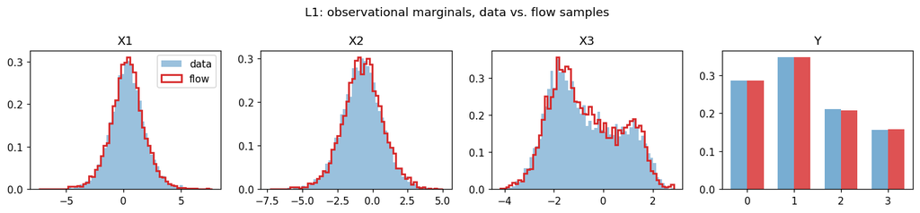

```python
samp = flow.sample(len(df), seed=0)

fig, axes = plt.subplots(1, 4, figsize=(13, 3))
for ax, col in zip(axes[:3], ["X1", "X2", "X3"]):
    bins = np.linspace(df[col].min(), df[col].max(), 60)
    ax.hist(df[col], bins=bins, density=True, alpha=0.45, label="data")
    ax.hist(
        samp[col],
        bins=bins,
        density=True,
        histtype="step",
        lw=1.8,
        color="C3",
        label="flow",
    )
    ax.set_title(col)
levels = np.arange(4)
w = 0.35
axes[3].bar(
    levels - w / 2,
    df["Y"].value_counts(normalize=True).sort_index(),
    width=w,
    alpha=0.6,
    label="data",
)
axes[3].bar(
    levels + w / 2,
    samp["Y"].value_counts(normalize=True).sort_index(),
    width=w,
    color="C3",
    alpha=0.8,
    label="flow",
)
axes[3].set_title("Y"), axes[3].set_xticks(levels)
axes[0].legend()
fig.suptitle("L1: observational marginals, data vs. flow samples")
fig.tight_layout()
plt.show()
```

## 6. Single-number interpretable statistics

Because the latents are standard logistic, every linear-shift weight is a **log-odds ratio**. For a continuous node ($z = h(x) + \beta\, x_{\text{pa}}$), a unit increase of the parent multiplies the odds of $\{X \le x\}$ by $e^\beta$ — uniformly in $x$ (a proportional-odds / Colr-type effect). For the ordinal node the sign convention flips ($\sigma(\vartheta_k - \text{shift})$), so a positive $\beta$ moves $Y$ towards higher categories: $e^\beta$ multiplies the odds of $\{Y > k\}$.

These are *parameters of the fitted flow* — we can simply read them off and compare with the DGP constants:

```python
b21_hat = float(flow.nodes["X2"].shifts["X1"].weight.detach())
b31_hat = float(flow.nodes["X3"].shifts["X1"].weight.detach())
bY_hat = float(flow.nodes["Y"].shifts["X3"].weight.detach())


with torch.no_grad():
    theta_hat = ordinal_cutpoints(flow.nodes["Y"].intercept(1))[0, 1:-1].numpy()

print(f"beta_21 (X1 -> X2):  true {TRUE['b21']:+.3f}   fitted {b21_hat:+.3f}")
print(f"beta_31 (X1 -> X3):  true {TRUE['b31']:+.3f}   fitted {b31_hat:+.3f}")
print(f"beta_Y  (X3 -> Y):   true {TRUE['bY']:+.3f}   fitted {bY_hat:+.3f}")
print(f"cutpoints theta_Y:   true {TRUE['theta_Y']}   fitted {theta_hat.round(3)}")
```

```
beta_21 (X1 -> X2):  true +1.500   fitted +1.486
beta_31 (X1 -> X3):  true +0.800   fitted +0.748
beta_Y  (X3 -> Y):   true +1.000   fitted +0.989
cutpoints theta_Y:   true [-2.   0.   1.5]   fitted [-2.011  0.019  1.587]
```

The flexible parts are recovered too. The baseline transformation $\hat h_3$ should match $\sinh$, and the complex shift $\hat g$ should match $\tfrac12 x_2^2$ — each **up to an additive constant**, because a constant can move freely between the intercept and a complex shift (only their sum is identified). We therefore center both curves before comparing.

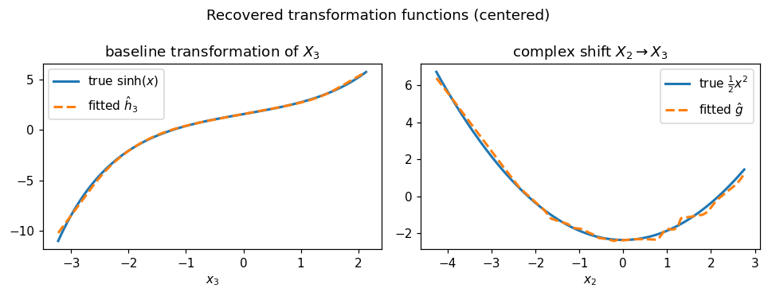

```python
def fitted_baseline(flow, name, grid):
    """h_hat(x) for a continuous node with constant (simple) intercept."""
    node = flow.nodes[name]
    x = torch.as_tensor(grid, dtype=torch.float32)
    with torch.no_grad():
        z0, _ = node.ut.forward(node.intercept(len(grid)), x)
    return z0.detach().numpy()


def fitted_cs(flow, name, parent, grid):
    """g_hat(parent) for a 'cs' edge."""
    x = torch.as_tensor(grid, dtype=torch.float32).view(-1, 1)
    with torch.no_grad():
        return flow.nodes[name].shifts[parent](x).detach().numpy()


x3_grid = np.linspace(*df["X3"].quantile([0.01, 0.99]), 200)
x2_grid = np.linspace(*df["X2"].quantile([0.01, 0.99]), 200)
h3_hat, h3_true = fitted_baseline(flow, "X3", x3_grid), np.sinh(x3_grid)
g_hat, g_true = fitted_cs(flow, "X3", "X2", x2_grid), g_cs(x2_grid)

fig, axes = plt.subplots(1, 2, figsize=(9, 3.4))
axes[0].plot(x3_grid, h3_true - h3_true.mean(), lw=2, label=r"true $\sinh(x)$")
axes[0].plot(x3_grid, h3_hat - h3_hat.mean(), "--", lw=2, label=r"fitted $\hat h_3$")
axes[0].set_title("baseline transformation of $X_3$"), axes[0].set_xlabel("$x_3$")
axes[1].plot(x2_grid, g_true - g_true.mean(), lw=2, label=r"true $\frac{1}{2}x^2$")
axes[1].plot(x2_grid, g_hat - g_hat.mean(), "--", lw=2, label=r"fitted $\hat g$")
axes[1].set_title("complex shift $X_2 \\to X_3$"), axes[1].set_xlabel("$x_2$")
for ax in axes:
    ax.legend()
fig.suptitle("Recovered transformation functions (centered)")
fig.tight_layout()
plt.show()
```

### Why the term choice matters: a deliberately misspecified model

```python
spec_ls = {
    "X1": ContinuousNode(transform="bernstein"),
    "X2": ContinuousNode(terms=[LS("X1")]),
    "X3": ContinuousNode(terms=[LS("X1"), LS("X2")]),  # <- cs replaced by ls
    "Y": OrdinalNode(levels=4, terms=[LS("X3")]),
}
torch.manual_seed(7)
flow_ls = CausalFlowDAG(spec_ls)
flow_ls.fit(train_df, val_df, epochs=800, learning_rate=1e-2, batch_size=512, verbose=0)
flow_ls.fit(train_df, val_df, epochs=300, learning_rate=1e-3, verbose=0)

print(
    f"misspecified beta_32 (X2 -> X3): "
    f"{float(flow_ls.nodes['X3'].shifts['X2'].weight.detach()):+.3f}"
)
print(
    f"val NLL of node X3:  cs model {flow.nll(val_df)['X3']:.4f}"
    f"   ls model {flow_ls.nll(val_df)['X3']:.4f}"
)
```

```
misspecified beta_32 (X2 -> X3): -0.608
val NLL of node X3:  cs model 1.1749   ls model 1.3800
```

## 7. Rung 2 — interventions: the do-operator

```
E[X3 | do(X1=-1)]:  truth +0.243   flow(cs) +0.175   flow(all-ls) +0.169
```

```
E[X3 | do(X1=+1)]:  truth -1.101   flow(cs) -1.129   flow(all-ls) -1.227
```

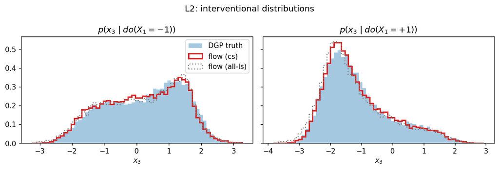

```python
rng_iv = np.random.default_rng(123)
fig, axes = plt.subplots(1, 2, figsize=(10, 3.4), sharey=True)
for ax, a in zip(axes, [-1.0, 1.0]):
    truth, _ = simulate(20000, rng_iv, x1=a)
    fl = flow.sample(20000, do={"X1": a}, seed=5)
    fls = flow_ls.sample(20000, do={"X1": a}, seed=5)
    bins = np.linspace(truth["X3"].min(), truth["X3"].max(), 60)
    ax.hist(truth["X3"], bins=bins, density=True, alpha=0.4, label="DGP truth")
    ax.hist(
        fl["X3"],
        bins=bins,
        density=True,
        histtype="step",
        lw=2,
        color="C3",
        label="flow (cs)",
    )
    ax.hist(
        fls["X3"],
        bins=bins,
        density=True,
        histtype="step",
        lw=1.5,
        color="C7",
        ls=":",
        label="flow (all-ls)",
    )
    ax.set_title(f"$p(x_3 \\mid do(X_1 = {a:+.0f}))$"), ax.set_xlabel("$x_3$")
    print(
        f"E[X3 | do(X1={a:+.0f})]:  truth {truth['X3'].mean():+.3f}   "
        f"flow(cs) {fl['X3'].mean():+.3f}   flow(all-ls) {fls['X3'].mean():+.3f}"
    )
axes[0].legend()
fig.suptitle("L2: interventional distributions")
fig.tight_layout()
plt.show()
```

For the **ordinal** outcome no Monte Carlo is needed: the ordered-logit head gives the interventional PMF **analytically**, $P(Y = k \mid do(X_3 = a)) = \sigma(\vartheta_k - \beta_Y a) - \sigma(\vartheta_{k-1} - \beta_Y a)$.

```python
a = 1.0
pmf_flow = flow.pmf(pd.DataFrame({"X3": [a]}), "Y")[0]
cdf_true = 1 / (1 + np.exp(-(np.r_[-np.inf, TRUE["theta_Y"], np.inf] - TRUE["bY"] * a)))
pmf_true = np.diff(cdf_true)
print("P(Y = k | do(X3 = 1)):")
print("  true:", pmf_true.round(4), "\n  flow:", pmf_flow.round(4))
```

```
P(Y = k | do(X3 = 1)):
  true: [0.0474 0.2215 0.3535 0.3775]
  flow: [0.0474 0.2274 0.3703 0.3549]
```

## 8. Rung 3 — counterfactuals: abduction → action → prediction

Because the flow is **bijective in the continuous variables**, Pearl's three steps are exact:

1. **Abduction** — map the *factual* data to its latent (the training direction): $u = h(x \mid \mathrm{pa})$ per node (`flow.abduct(df)`). Each row's $u$ is its individual "noise", everything about the unit that the model does not attribute to the parents. (For ordinal nodes $u$ is only interval-identified, so it is drawn from the logistic truncated to the observed level's interval.)
2. **Action** — mutilate the graph: `do={"X1": 0.0}`.
3. **Prediction** — push the *same* $u$ back through the mutilated flow: `flow.sample(do=..., u=u)`.

First check: with no action at all, pushing the abducted latents through the flow must reproduce the factual data exactly (level-exactly for $Y$).

```python
u = flow.abduct(val_df, seed=11)
recon = flow.sample(u=u)
err = recon[["X1", "X2", "X3"]].to_numpy() - val_df[["X1", "X2", "X3"]].to_numpy()
print(f"max |reconstruction error| (continuous): {np.abs(err).max():.2e}")
print(f"Y level-exact: {(recon['Y'].to_numpy() == val_df['Y'].to_numpy()).mean():.1%}")
```

```
max |reconstruction error| (continuous): 1.15e-05
Y level-exact: 100.0%
```

Now the counterfactual *"what would $X_2, X_3$ have been for **this** unit, had $X_1$ been 0?"*. The DGP kept every unit's true latents `z_obs`, so we can compute the **true individual counterfactuals** and compare unit by unit — the strongest test on the ladder.

```
counterfactual X2:  corr(truth, flow) = 0.9999   RMSE = 0.013
counterfactual X3:  corr(truth, flow) = 0.9962   RMSE = 0.108
```

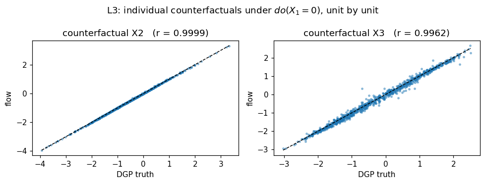

```python
cf_flow = flow.sample(do={"X1": 0.0}, u=u)
z_val = {k: v[5000:] for k, v in z_obs.items()}
cf_true, _ = simulate(len(val_df), rng, x1=0.0, z=z_val)

fig, axes = plt.subplots(1, 2, figsize=(9, 3.4))
for ax, col in zip(axes, ["X2", "X3"]):
    ax.scatter(cf_true[col], cf_flow[col], s=5, alpha=0.4)
    lims = [cf_true[col].min(), cf_true[col].max()]
    ax.plot(lims, lims, "k--", lw=1)
    r = np.corrcoef(cf_true[col], cf_flow[col])[0, 1]
    rmse = float(np.sqrt(np.mean((cf_true[col] - cf_flow[col]) ** 2)))
    print(f"counterfactual {col}:  corr(truth, flow) = {r:.4f}   RMSE = {rmse:.3f}")
    ax.set_title(f"counterfactual {col}   (r = {r:.4f})")
    ax.set_xlabel("DGP truth"), ax.set_ylabel("flow")
fig.suptitle("L3: individual counterfactuals under $do(X_1 = 0)$, unit by unit")
fig.tight_layout()
plt.show()
```

## 9. Where to go from here

- **Complex intercepts (`I(...)`)** — the one component not exercised here: declare `terms=[I("Age")]` and the *parameters* of the Bernstein transform become a function of the parent (several `I(...)` parents feed one joint network, i.e. they may interact). The stroke experiments in `experiments/` use `I(...)` heavily; run `uv run python experiments/sim_flow.py nl` for the full storyline on the synthetic cohort with known ground truth.
- **Early stopping vs. exact MLE** — this notebook's DGP has no unobserved confounding, so the MLE (`restore_best=False`, the default) is the right target. On the synthetic stroke cohort, flexible (`ci`/`cs`) models *overfit observational confounding* at the MLE and need `restore_best=True` to recover the causal effect — see `CHANGELOG.md` and the README's "Results" notes.
- **Validation against classical models** — an all-`ls` flow trained to convergence *is* the classical proportional-odds MLE (`experiments/validate_ls.py` pins flow ≡ `statsmodels` ≡ R `polr`).
- **Joint terms** — write several parents inside one term to model an *interaction*: `CS("x1", "x2")` is a single shift network $g(x_1, x_2)$, and `I("x1", "x2")` a single intercept network over both parents. Separate terms (`CS("x1") + CS("x2")`) stay additive — the grouping *is* the joint/additive choice.
- **Current limitations** (vs. the general formulation): the latent is fixed to the standard logistic.

*Generated as a jupytext percent notebook — pair it with `uvx jupytext --to ipynb notebooks/intro_tram_dag.py` if you prefer `.ipynb`, and keep the `.ipynb` out of git (see `.gitignore`).*